# Workshop 6

```r
library(dplyr)
library(ggplot2)
```

I got a little ahead of myself last time and said we finished all the core R material. In fact, there’s one last thing remaining to master and that is {ggplot2} for plotting in R.

# 1 Introduction

## 1.1 Learning Objectives

1. Learn how to create visualizations using {ggplot2}

# 2 Plotting in R

While R is a great platform for data analysis in general, one area in which it really shines is in creating visualizations. This is enabled through a very powerful graphics library called {ggplot2}. As before, there exists a great cheat-sheet for {ggplot2} [here](https://github.com/rstudio/cheatsheets/blob/master/data-visualization-2.1.pdf).

If you have a keen eye, you might observe that plots in many publications are built in {ggplot2}: this is no coincidence. It’s over 10 years old with hundreds of thousands of users and comprehensive documentation. As such, there are also countless online and print tutorials on it (see [links from the tidyverse](https://ggplot2.tidyverse.org/)) if you still want more after this worksheet.

## 2.1 Examining Output

By default, R sends all plotting output to the current chunk (in .Rmd files) or the Plots tab in the bottom right corner of RStudio (when run from the console or in a .R file).

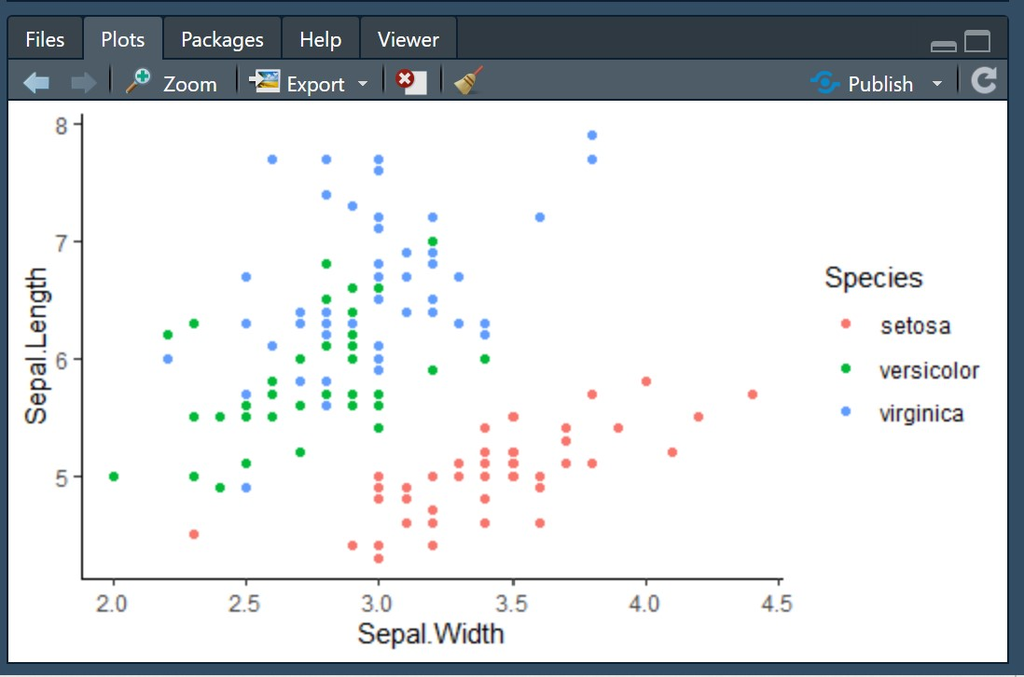

You can pop the plot into a full screen tab by clicking on the `Zoom` button in that display. You can also save your plots to disk from that window by clicking on `Export` and selecting the options you’d like to use.

## 2.2 Generating Output

Plotting is achieved (in large part) by use of {ggplot2}. To use this package, you have to install it and load it as usual:

```r
install.packages('ggplot2') # Only run once
library(ggplot2) # Run whenever you want to use ggplot
```

Once installed and loaded, you’re ready to generate plots!

The data that you’ll plot will almost always in the form of a data frame with each observation you want to plot in one row. This is what we call “tidy data” as we saw before. It’s thus important that we’re able to wrangle our data into this kind of format using the various `melt`, `merge`, `dcast` and other data processing techniques we learned in the previous worksheets. Whenever you’re getting ready to plot data, always ask yourself if every point you want to plot is on a row, and every feature you want to plot is on a column.

**Your task:** Base R provides a dataset called `trees` which contains data on 31 black cherry trees. Examine the data and consider a scenario where you want to plot the correspondence between `Girth` and `Height`: is the data tidy for this purpose? If not, use your data wrangling techniques to make it tidy. Remember to load the appropriate libraries if you need to.

```r
# TODO Your answer here
```

```r
head(trees)
# The data is already tidy:
# 1. each row is an observation (tree)
# 2. each feature we want to plot (Girth, Height) is on a column
```

**Your task:** The {tidyr} package contains information on the billboard top 100 for the year 2000 in `tidyr::billboard` where every number is a ranking for the corresponding `artist` and `track`. Examine the data there. Now consider a scenario where you want to plot a particular song’s billboard rank over time: is the data tidy for this purpose? If not, use your data wrangling techniques to make it tidy. Remember to load the appropriate libraries if you need to.

```r
# TODO Your answer here
```

```r
head(tidyr::billboard)
# The data is not tidy. We want to plot data over time, which implies that we want a column for "time". Instead, we have a column for each week, so we need to wrangle our data.
library(reshape2) # We'll use reshape2 to melt weeks into one column
melt(tidyr::billboard, id.vars = 1:3, variable.name = 'week')
```